# Capstone Project: Create a Customer Segmentation Report for Arvato Financial Services

**Sebastian Uribe**

December , 2019

In this project, I am going to analyze demographics data for customers of a mail-order sales company in Germany, comparing it against demographics information for the general population. The goal is to use unsupervised learning techniques to perform customer segmentation, identifying the parts of the population that best describe the core customer base of the company.

Second part required desing a a model that predicts which individuals are most likely to convert into becoming customers for the company.

Arvato Bertelsman (Financial Solutions Division) is an international financial service provider from Germany, they offer solutions related to ID & Fraud Managemet, Credit Risk Management, Payment & Financing Services and Debt Collection Services. Like every company with a marketing department, it is important to understand who their customers are, what are their characteristics, how is their payment behavior and more, all important information to provide a good service, but most importantly to keep profits up !.

For any company( not only Arvato ), designing efficient marketing campaign on how to acquire new customers is not an easy task, it involves a series of multiple studies to understand customers information and design strategic campaigns to maximize customer’s acquisition taking into consideration the cost of the campaign. You can’t just send ads to any non-client with publicity, too much money spend and with little ROI 1, its more effective to send ads to those who shares similar characteristics to your already clients. The big and important questions is "what are those characteristics that groups my clients based on their characteristics ?". Thankfully some Machine learning methods we can answer it.

## Problem Statement

The goal of this project is to perform and analyze a customer segmentation that allows the principal characteristics of the core business customers. This finding’s will be later be used as part of information to predict which individuals are most likely to convert into new customers. From Arvatos perspective, this project might help answering the following questions:

• How can the mail-order company acquire new clients more efficiently. \ • Which people are most likely new customers ?

This kind of problem is both an unsupervised and supervised machine learning problem. For the unsupervised part of the project, we are provided with features of demographic data from population of Germany and customers of the mail-order company to apply any clustering technic looking patterns to segment posible clients. There is not right anwser here, but the answer must be according to the financial needs of Arvato. For the supervised part, it is clearly a classification problem, with a binary target that represents which individuals are most likely to be new customers (Represented as 1) and those who are not very liekly (Represented as 0).

## Evaluation Metrics

**Customer Segmentation Stage** : Commonly, unsupervised models don't have a right answer, this must depend on the type of problem and the business goals, but we can use the [Silhouette Score](https://scikit-learn.org/stable/modules/generated/sklearn.metrics.silhouette_score.html) to get an idea of consistency within the clusters, where the intra-cluster distance (a) and the mean nearest-cluster distance (b) is calculated for each sample.

The Silhouette Coefficient for a sample is :

$$Silhouette Coefficient = {(b-a)\over max(a,b)}.$$

Same again, without knowing much about the business goal we can use the [Elbow Method Heuristic](https://www.oreilly.com/library/view/statistics-for-machine/9781788295758/c71ea970-0f3c-4973-8d3a-b09a7a6553c1.xhtml) to determine the optimal number of clusters by measuring the within cluster sum of errors (*WCSS*). *WCSS* is the summation of the each clusters distance between that specific clusters each points against the cluster centroid.

**Supervised Stage** :

Area Under the Receiver Operating Characteristic Curve [ROC AUC](https://scikit-learn.org/stable/modules/generated/sklearn.metrics.roc_auc_score.html) is a common metric used when predicting the probability for binary classifiers, since this is the evaluation metric at the [Kaggle - Udacity challengue](https://www.kaggle.com/c/udacity-arvato-identify-customers/overview/evaluation), this will be the metric to evaluated the selected model.

```python
# import libraries here; add more as necessary
import numpy as np
import pandas as pd
import matplotlib.pyplot as plt
import seaborn as sns
import warnings
warnings.filterwarnings('ignore')
# magic word for producing visualizations in notebook
%matplotlib inline
```

## Part 0: Get to Know the Data

There are four data files associated with this project:

data can be found in [Kaggle](https://www.kaggle.com/c/udacity-arvato-identify-customers/data)

Each row of the demographics files represents a single person, but also includes information outside of individuals, including information about their household, building, and neighborhood. Use the information from the first two files to figure out how customers ("CUSTOMERS") are similar to or differ from the general population at large ("AZDIAS"), then use your analysis to make predictions on the other two files ("MAILOUT"), predicting which recipients are most likely to become a customer for the mail-order company.

The "CUSTOMERS" file contains three extra columns ('CUSTOMER_GROUP', 'ONLINE_PURCHASE', and 'PRODUCT_GROUP'), which provide broad information about the customers depicted in the file. The original "MAILOUT" file included one additional column, "RESPONSE", which indicated whether or not each recipient became a customer of the company. For the "TRAIN" subset, this column has been retained, but in the "TEST" subset it has been removed; it is against that withheld column that your final predictions will be assessed in the Kaggle competition.

Otherwise, all of the remaining columns are the same between the three data files. For more information about the columns depicted in the files, you can refer to two Excel spreadsheets provided in the workspace. One of them is a top-level list of attributes and descriptions, organized by informational category. The other is a detailed mapping of data values for each feature in alphabetical order.

```python
# load in the data
azdias = pd.read_csv('data/Udacity_AZDIAS_052018.csv', sep=';')
```

```python
azdias.info()
```

```
<class 'pandas.core.frame.DataFrame'>
RangeIndex: 891221 entries, 0 to 891220
Columns: 366 entries, LNR to ALTERSKATEGORIE_GROB
dtypes: float64(267), int64(93), object(6)
memory usage: 2.4+ GB
```

```python
azdias.head()
```

|  | LNR | AGER_TYP | AKT_DAT_KL | ALTER_HH | ALTER_KIND1 | ALTER_KIND2 | ALTER_KIND3 | ALTER_KIND4 | ALTERSKATEGORIE_FEIN | ANZ_HAUSHALTE_AKTIV | ... | VHN | VK_DHT4A | VK_DISTANZ | VK_ZG11 | W_KEIT_KIND_HH | WOHNDAUER_2008 | WOHNLAGE | ZABEOTYP | ANREDE_KZ | ALTERSKATEGORIE_GROB |
| --- | --- | --- | --- | --- | --- | --- | --- | --- | --- | --- | --- | --- | --- | --- | --- | --- | --- | --- | --- | --- | --- |
| 0 | 910215 | -1 | NaN | NaN | NaN | NaN | NaN | NaN | NaN | NaN | ... | NaN | NaN | NaN | NaN | NaN | NaN | NaN | 3 | 1 | 2 |
| 1 | 910220 | -1 | 9.0 | 0.0 | NaN | NaN | NaN | NaN | 21.0 | 11.0 | ... | 4.0 | 8.0 | 11.0 | 10.0 | 3.0 | 9.0 | 4.0 | 5 | 2 | 1 |
| 2 | 910225 | -1 | 9.0 | 17.0 | NaN | NaN | NaN | NaN | 17.0 | 10.0 | ... | 2.0 | 9.0 | 9.0 | 6.0 | 3.0 | 9.0 | 2.0 | 5 | 2 | 3 |
| 3 | 910226 | 2 | 1.0 | 13.0 | NaN | NaN | NaN | NaN | 13.0 | 1.0 | ... | 0.0 | 7.0 | 10.0 | 11.0 | NaN | 9.0 | 7.0 | 3 | 2 | 4 |
| 4 | 910241 | -1 | 1.0 | 20.0 | NaN | NaN | NaN | NaN | 14.0 | 3.0 | ... | 2.0 | 3.0 | 5.0 | 4.0 | 2.0 | 9.0 | 3.0 | 4 | 1 | 3 |

5 rows × 366 columns

```python
azdias.shape
```

```
(891221, 366)
```

mmmm it seems there are missing values , lest check that

## Features Missing

```python
from utils import missing_values_table
```

```python
azdias_missing=missing_values_table(azdias)
```

```
El dataframe tiene 366 columnas.
De las cuales a 273 le faltan datos.
```

```python
azdias_missing.head(10)
```

|  | Missing | % of Total Values |
| --- | --- | --- |
| ALTER_KIND4 | 890016 | 99.9 |
| ALTER_KIND3 | 885051 | 99.3 |
| ALTER_KIND2 | 861722 | 96.7 |
| ALTER_KIND1 | 810163 | 90.9 |
| EXTSEL992 | 654153 | 73.4 |
| KK_KUNDENTYP | 584612 | 65.6 |
| ALTERSKATEGORIE_FEIN | 262947 | 29.5 |
| D19_SOZIALES | 257113 | 28.8 |
| D19_LOTTO | 257113 | 28.8 |
| D19_BANKEN_ONLINE_QUOTE_12 | 257113 | 28.8 |

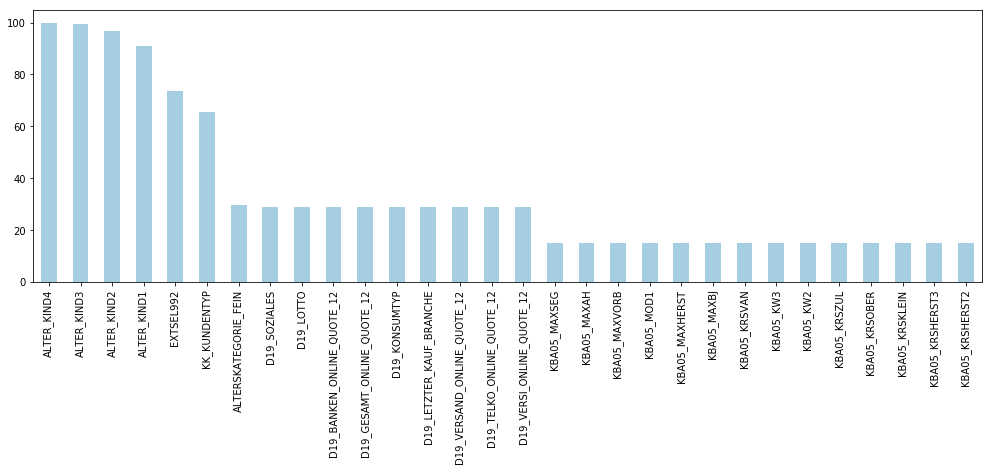

```python
azdias_missing['% of Total Values'].head(30).plot(kind ='bar', figsize=(17,5),colormap='Paired')
```

It appears that there are some feature with missing values, but according to *DIAS Attributes-Values 2017_modify.xlsx*

it could be worse than expected, some features are represented with -1 or 0 when the data is missing or unkonw.

Using the *DIAS Attributes-Values 2017.xlsx* file we can use it to complete missing data and replace it with proper values used in the file. Based on this file, I created the dias_unkown.csv file (For the Creation of the file please refer to the data data_script.py. This file can be used to understand wich value correspond to a unknown o missing data.

```python
dias = pd.read_csv('data/dias_unknown.csv',sep=';')
```

```python
dias.head(10)
```

|  | Attribute | Meaning | Value | Unknown_0 | Unknown_1 |
| --- | --- | --- | --- | --- | --- |
| 0 | AGER_TYP | unknown | -1 | NaN | NaN |
| 1 | ALTERSKATEGORIE_GROB | unknown | -1, 0 | -1.0 | 0.0 |
| 2 | ALTER_HH | unknown / no main age detectable | 0 | NaN | NaN |
| 3 | ANREDE_KZ | unknown | -1, 0 | -1.0 | 0.0 |
| 4 | BALLRAUM | unknown | -1 | NaN | NaN |
| 5 | BIP_FLAG | unknown | -1 | NaN | NaN |
| 6 | CAMEO_DEUG_2015 | unknown | -1 | NaN | NaN |
| 7 | CAMEO_DEUINTL_2015 | unknown | -1 | NaN | NaN |
| 8 | CJT_GESAMTTYP | unknown | 0 | NaN | NaN |
| 9 | D19_BANKEN_ANZ_12 | no transactions known | 0 | NaN | NaN |

```python
values_to_replace=dias.set_index('Attribute').to_dict()['Value']
```

Since there are some features that has 2 possible options when the value is unknown, I created the following function that will replace those value according to the dias_unknown.csv, first It will evaluated if a feature has 2 possible options when the value is unknown and will unified them for the first value that appears in the Value columns, then it will replace missing values with **NaN**

```python
from os import path
```

This takes some time, it will be usefull to save the dataset

```python
%%time
if path.exists("data/azdias_with_nan.csv")==False:
    for col in azdias.columns:
        if col in dias.Attribute.unique():
            if(len(values_to_replace[col].split(','))>1):
                azdias.loc[azdias[col]==int(values_to_replace[col].split(',')[1]), col] = int(values_to_replace[col].split(',')[0])
                azdias.loc[azdias[col]==int(values_to_replace[col].split(',')[0]), col] = np.nan
            else:
                azdias.loc[azdias[col]==int(values_to_replace[col]), col] = np.nan
    azdias.to_csv('data/azdias_with_nan.csv',index=False,sep=';')
else:
    print('File Exist!, Dont Worry, opening : azdias_with_nan.csv')
    azdias=pd.read_csv('data/azdias_with_nan.csv',sep=';')
```

```
File Exist!, Dont Worry, opening : azdias_with_nan.csv
Wall time: 20.2 s
```

```python
azdias.head()
```

|  | LNR | AGER_TYP | AKT_DAT_KL | ALTER_HH | ALTER_KIND1 | ALTER_KIND2 | ALTER_KIND3 | ALTER_KIND4 | ALTERSKATEGORIE_FEIN | ANZ_HAUSHALTE_AKTIV | ... | VHN | VK_DHT4A | VK_DISTANZ | VK_ZG11 | W_KEIT_KIND_HH | WOHNDAUER_2008 | WOHNLAGE | ZABEOTYP | ANREDE_KZ | ALTERSKATEGORIE_GROB |
| --- | --- | --- | --- | --- | --- | --- | --- | --- | --- | --- | --- | --- | --- | --- | --- | --- | --- | --- | --- | --- | --- |
| 0 | 910215 | NaN | NaN | NaN | NaN | NaN | NaN | NaN | NaN | NaN | ... | NaN | NaN | NaN | NaN | NaN | NaN | NaN | 3.0 | 1.0 | 2.0 |
| 1 | 910220 | NaN | 9.0 | NaN | NaN | NaN | NaN | NaN | 21.0 | 11.0 | ... | 4.0 | 8.0 | 11.0 | 10.0 | 3.0 | 9.0 | 4.0 | 5.0 | 2.0 | 1.0 |
| 2 | 910225 | NaN | 9.0 | 17.0 | NaN | NaN | NaN | NaN | 17.0 | 10.0 | ... | 2.0 | 9.0 | 9.0 | 6.0 | 3.0 | 9.0 | 2.0 | 5.0 | 2.0 | 3.0 |
| 3 | 910226 | 2.0 | 1.0 | 13.0 | NaN | NaN | NaN | NaN | 13.0 | 1.0 | ... | 0.0 | 7.0 | 10.0 | 11.0 | NaN | 9.0 | 7.0 | 3.0 | 2.0 | 4.0 |
| 4 | 910241 | NaN | 1.0 | 20.0 | NaN | NaN | NaN | NaN | 14.0 | 3.0 | ... | 2.0 | 3.0 | 5.0 | 4.0 | 2.0 | 9.0 | 3.0 | 4.0 | 1.0 | 3.0 |

5 rows × 366 columns

```python
azdias_missing=missing_values_table(azdias)
```

```
El dataframe tiene 366 columnas.
De las cuales a 333 le faltan datos.
```

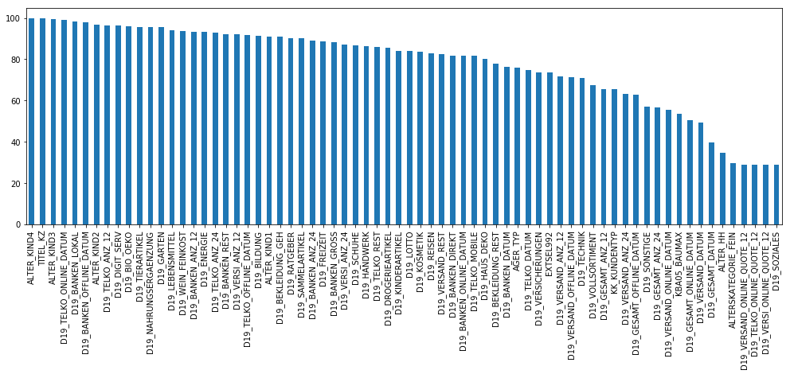

```python
azdias_missing['% of Total Values'].head(70).plot(kind ='bar', figsize=(17,5))
```

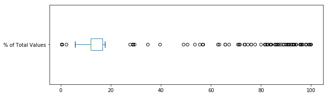

```python
azdias_missing['% of Total Values'].plot(kind ='box', figsize=(10,3),vert=False)
```

Still there are features with a lot of missing values. I set a Threshold of 30 % since I could be leading to a duplicated to much information that it becomes noise.

```python
missing_columns_to_drop=azdias_missing[azdias_missing['% of Total Values']>=30].index
missing_columns_to_drop
```

```
Index(['ALTER_KIND4', 'TITEL_KZ', 'ALTER_KIND3', 'D19_TELKO_ONLINE_DATUM',
       'D19_BANKEN_LOKAL', 'D19_BANKEN_OFFLINE_DATUM', 'ALTER_KIND2',
       'D19_TELKO_ANZ_12', 'D19_DIGIT_SERV', 'D19_BIO_OEKO', 'D19_TIERARTIKEL',
       'D19_NAHRUNGSERGAENZUNG', 'D19_GARTEN', 'D19_LEBENSMITTEL',
       'D19_WEIN_FEINKOST', 'D19_BANKEN_ANZ_12', 'D19_ENERGIE',
       'D19_TELKO_ANZ_24', 'D19_BANKEN_REST', 'D19_VERSI_ANZ_12',
       'D19_TELKO_OFFLINE_DATUM', 'D19_BILDUNG', 'ALTER_KIND1',
       'D19_BEKLEIDUNG_GEH', 'D19_RATGEBER', 'D19_SAMMELARTIKEL',
       'D19_BANKEN_ANZ_24', 'D19_FREIZEIT', 'D19_BANKEN_GROSS',
       'D19_VERSI_ANZ_24', 'D19_SCHUHE', 'D19_HANDWERK', 'D19_TELKO_REST',
       'D19_DROGERIEARTIKEL', 'D19_KINDERARTIKEL', 'D19_LOTTO', 'D19_KOSMETIK',
       'D19_REISEN', 'D19_VERSAND_REST', 'D19_BANKEN_DIREKT',
       'D19_BANKEN_ONLINE_DATUM', 'D19_TELKO_MOBILE', 'D19_HAUS_DEKO',
       'D19_BEKLEIDUNG_REST', 'D19_BANKEN_DATUM', 'AGER_TYP',
       'D19_TELKO_DATUM', 'D19_VERSICHERUNGEN', 'EXTSEL992',
       'D19_VERSAND_ANZ_12', 'D19_VERSAND_OFFLINE_DATUM', 'D19_TECHNIK',
       'D19_VOLLSORTIMENT', 'D19_GESAMT_ANZ_12', 'KK_KUNDENTYP',
       'D19_VERSAND_ANZ_24', 'D19_GESAMT_OFFLINE_DATUM', 'D19_SONSTIGE',
       'D19_GESAMT_ANZ_24', 'D19_VERSAND_ONLINE_DATUM', 'KBA05_BAUMAX',
       'D19_GESAMT_ONLINE_DATUM', 'D19_VERSAND_DATUM', 'D19_GESAMT_DATUM',
       'ALTER_HH'],
      dtype='object')
```

```python
azdias.drop(missing_columns_to_drop,axis=1,inplace=True)
```

```python
azdias_missing_2=missing_values_table(azdias)
```

```
El dataframe tiene 301 columnas.
De las cuales a 268 le faltan datos.
```

## Rows with Missing data

Lets Check percentage of missing values pair row

```python
clients_missing_data=(azdias.isnull().sum(axis=1)*100)/azdias.shape[1]
```

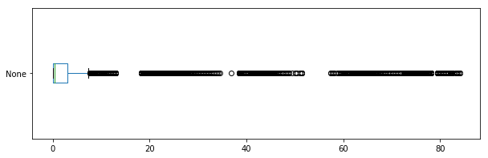

```python
clients_missing_data.plot(kind='box', figsize=(10,3),vert=False)
```

There are a lot of clients that are missing a lot of information, those clients might be not worth saving, since the final output will be a client with almost every feature fill with the mean, median or mode of the corresponding feature.

```python
sum(clients_missing_data>25)
```

```
107950
```

```python
azdias.shape
```

```
(891221, 301)
```

```python
azdias.dropna(thresh=250,inplace=True)
```

```python
azdias.shape
```

```
(737288, 301)
```

## Cleaning and Preprocessing

An strategy to deal with the rest of features with **NaN**m will be imputation with median or most frequent value. Statistcally this doesnt affect the feautre distribution. This is way much butter than dropping points as also it gives more accurate results than dropping data points or columns entirely.

- Numerical data will be imputed with median value in the column to deal with outliers.
- Categorial data will be imputed with the most frequent value.

```python
azdias_columns_impute = azdias_missing_2.index
```

I create a file name *data_types.csv* manually, checking each feature with the DIALES Files to determine if a columns was numeric, categorical , or datetime. I add a column to express if the categorical feature can be represented in an ordinal way or needs to be represented in one hot encoding. Aditionaly I created an Anotations columns where I wrote some notes regarding to the preprocess. Maybe this can be enconde in python Rules but, it is safer to check every column manually one by one.

```python
azdias_dtypes = pd.read_csv('files/data_types.csv',sep=';')
```

```python
azdias_dtypes.head()
```

|  | Attribute | Feature_Type | Type | Anotations |
| --- | --- | --- | --- | --- |
| 0 | AGER_TYP | Category | OHE | NaN |
| 1 | ALTERSKATEGORIE_GROB | Category | Ordinal | NaN |
| 2 | ALTER_HH | datetime | NaN | Re Encode |
| 3 | ANREDE_KZ | Category | OHE | NaN |
| 4 | ANZ_HAUSHALTE_AKTIV | Numeric | NaN | NaN |

```python
azdias_dtypes[~azdias_dtypes.Anotations.isnull()]
```

|  | Attribute | Feature_Type | Type | Anotations |
| --- | --- | --- | --- | --- |
| 2 | ALTER_HH | datetime | NaN | Re Encode |
| 10 | CAMEO_DEUG_2015 | Category | Ordinal | Replace X |
| 269 | LP_FAMILIE_GROB | Category | OHE | Replace |
| 270 | LP_LEBENSPHASE_FEIN | Category | OHE | CHECK |
| 271 | LP_LEBENSPHASE_GROB | Category | OHE | CHECK |
| 272 | LP_STATUS_FEIN | Category | OHE | CHECK |
| 273 | LP_STATUS_GROB | Category | OHE | Replace |
| 287 | PRAEGENDE_JUGENDJAHRE | Category | OHE | Re Encode |
| 307 | TITEL_KZ | Category | OHE | RE_ENCODE |
| 319 | CAMEO_INTL_2015 | Category | Ordinal | Replace Values XX |
| 353 | LNR | Category | OHE | ID |

ALTER_HH and TITEL_KZ were droped due to much missing information

LP_LEBENSPHASE_FEIN shares almost the same information! as LP_LEBENSPHASE_GROB.

We can drop LP_LEBENSPHASE_FEIN . Another column to drop!

```python
azdias.drop(['LP_LEBENSPHASE_FEIN'],axis=1,inplace=True)
```

### ID

```python
azdias['LNR'].nunique() # THIS IS THE ID
```

```
737288
```

```python
azdias.set_index('LNR',inplace=True)
```

### XX values

```python
azdias['CAMEO_INTL_2015']=azdias['CAMEO_INTL_2015'].replace('XX',np.nan)
azdias['CAMEO_INTL_2015']=azdias['CAMEO_INTL_2015'].astype('float')

azdias['CAMEO_DEUG_2015']=azdias['CAMEO_DEUG_2015'].replace('X',np.nan)
azdias['CAMEO_DEUG_2015']=azdias['CAMEO_DEUG_2015'].astype('float')

azdias['CAMEO_DEU_2015']=azdias['CAMEO_DEU_2015'].replace('X',np.nan)
azdias['CAMEO_DEU_2015']=azdias['CAMEO_DEU_2015'].replace('XX',np.nan)
```

### Replace

```python
# single parent is 3,4,5 , Family 6,7,8 multiperson household 9,10,11

azdias.replace({'LP_FAMILIE_GROB' : { 4 : 3,
                                      5 : 3,
                                      7 : 6,
                                      8 : 6,
                                      10: 9,
                                      11: 9}}, inplace =True)
```

```python
# Social_Status 1,2: low-income earners | 3,4,5: average earners | 6,7: independants | 8,9: houseowners | 10: top earners
azdias.replace({'LP_STATUS_GROB' :  { 2 : 1,
                                      4 : 3,
                                      5 : 3,
                                      7 : 6,
                                      9 : 8,}}, inplace =True)
```

### Engineer Mixed-Type Features

```
                    PRAEGENDE_JUGENDJAHRE
```

| Value | Meaning |
| --- | --- |
| -1, 0 | unknown |
| 1 | 40ies - war years (Mainstream, O+W) |
| 2 | 40ies - reconstruction years (Avantgarde, O+W) |
| 3 | 50ies - economic miracle (Mainstream, O+W) |
| 4 | 50ies - milk bar / Individualisation (Avantgarde, O+W) |
| 5 | 60ies - economic miracle (Mainstream, O+W) |
| 6 | 60ies - generation 68 / student protestors (Avantgarde, W) |
| 7 | 60ies - opponents to the building of the Wall (Avantgarde, O) |
| 8 | 70ies - family orientation (Mainstream, O+W) |
| 9 | 70ies - peace movement (Avantgarde, O+W) |
| 10 | 80ies - Generation Golf (Mainstream, W) |
| 11 | 80ies - ecological awareness (Avantgarde, W) |
| 12 | 80ies - FDJ / communist party youth organisation (Mainstream, O) |
| 13 | 80ies - Swords into ploughshares (Avantgarde, O) |
| 14 | 90ies - digital media kids (Mainstream, O+W) |
| 15 | 90ies - ecological awareness (Avantgarde, O+W) |

```python
PRAEGENDE_JUGENDJAHRE = pd.read_excel('files/PRAEGENDE_JUGENDJAHRE.xlsx')
```

```python
PRAEGENDE_JUGENDJAHRE_unknown=PRAEGENDE_JUGENDJAHRE[PRAEGENDE_JUGENDJAHRE['Value']==-1]
PRAEGENDE_JUGENDJAHRE=PRAEGENDE_JUGENDJAHRE[PRAEGENDE_JUGENDJAHRE['Value']!=-1]
```

```python
PRAEGENDE_JUGENDJAHRE['GENERATION_DECADE']=PRAEGENDE_JUGENDJAHRE['Meaning'].apply(lambda x:x.split('-')[0])
PRAEGENDE_JUGENDJAHRE['Type']=PRAEGENDE_JUGENDJAHRE['Meaning'].apply(lambda x:x.split('-')[1].split('(')[0].split('(')[0])
PRAEGENDE_JUGENDJAHRE['MOVEMENT']=PRAEGENDE_JUGENDJAHRE['Meaning'].str.extract(pat = '(\(\w*,)')
PRAEGENDE_JUGENDJAHRE['MOVEMENT']=PRAEGENDE_JUGENDJAHRE['MOVEMENT'].str.strip('(,')
PRAEGENDE_JUGENDJAHRE['SECTOR']=PRAEGENDE_JUGENDJAHRE['Meaning'].apply(lambda x:x.split(',')[1])
PRAEGENDE_JUGENDJAHRE['SECTOR']=PRAEGENDE_JUGENDJAHRE['SECTOR'].str.strip(')')
```

```python
PRAEGENDE_JUGENDJAHRE=pd.concat([PRAEGENDE_JUGENDJAHRE_unknown, PRAEGENDE_JUGENDJAHRE])
```

```python
PRAEGENDE_JUGENDJAHRE
```

|  | GENERATION_DECADE | MOVEMENT | Meaning | SECTOR | Type | Value |
| --- | --- | --- | --- | --- | --- | --- |
| 0 | NaN | NaN | unknown | NaN | NaN | -1 |
| 1 | 40ies | Mainstream | 40ies - war years (Mainstream, O+W) | O+W | war years | 1 |
| 2 | 40ies | Avantgarde | 40ies - reconstruction years (Avantgarde, O+W) | O+W | reconstruction years | 2 |
| 3 | 50ies | Mainstream | 50ies - economic miracle (Mainstream, O+W) | O+W | economic miracle | 3 |
| 4 | 50ies | Avantgarde | 50ies - milk bar / Individualisation (Avantgar... | O+W | milk bar / Individualisation | 4 |
| 5 | 60ies | Mainstream | 60ies - economic miracle (Mainstream, O+W) | O+W | economic miracle | 5 |
| 6 | 60ies | Avantgarde | 60ies - generation 68 / student protestors (Av... | W | generation 68 / student protestors | 6 |
| 7 | 60ies | Avantgarde | 60ies - opponents to the building of the Wall ... | O | opponents to the building of the Wall | 7 |
| 8 | 70ies | Mainstream | 70ies - family orientation (Mainstream, O+W) | O+W | family orientation | 8 |
| 9 | 70ies | Avantgarde | 70ies - peace movement (Avantgarde, O+W) | O+W | peace movement | 9 |
| 10 | 80ies | Mainstream | 80ies - Generation Golf (Mainstream, W) | W | Generation Golf | 10 |
| 11 | 80ies | Avantgarde | 80ies - ecological awareness (Avantgarde, W) | W | ecological awareness | 11 |
| 12 | 80ies | Mainstream | 80ies - FDJ / communist party youth organisati... | O | FDJ / communist party youth organisation | 12 |
| 13 | 80ies | Avantgarde | 80ies - Swords into ploughshares (Avantgarde, O) | O | Swords into ploughshares | 13 |
| 14 | 90ies | Mainstream | 90ies - digital media kids (Mainstream, O+W) | O+W | digital media kids | 14 |
| 15 | 90ies | Avantgarde | 90ies - ecological awareness (Avantgarde, O+W) | O+W | ecological awareness | 15 |

### IMPUTE

```python
azdias_dtypes.Feature_Type.value_counts()
```

```
Category    357
Numeric       9
datetime      3
Name: Feature_Type, dtype: int64
```

```python
azdias_dtypes.groupby(['Feature_Type','Type'])['Type'].count()
```

```
Feature_Type  Type
Category      OHE         45
              Ordinal    312
Name: Type, dtype: int64
```

```python
azdias_dtypes[azdias_dtypes.Attribute.isin(azdias_columns_impute)].Feature_Type.value_counts()
```

```
Category    258
Numeric       8
datetime      2
Name: Feature_Type, dtype: int64
```

```python
azdias_dtypes[azdias_dtypes.Feature_Type=='Numeric ']
```

|  | Attribute | Feature_Type | Type | Anotations |
| --- | --- | --- | --- | --- |
| 4 | ANZ_HAUSHALTE_AKTIV | Numeric | NaN | NaN |
| 5 | ANZ_HH_TITEL | Numeric | NaN | NaN |
| 6 | ANZ_PERSONEN | Numeric | NaN | NaN |
| 7 | ANZ_TITEL | Numeric | NaN | NaN |
| 85 | GEBURTSJAHR | Numeric | NaN | NaN |
| 162 | KBA13_ANZAHL_PKW | Numeric | NaN | NaN |
| 274 | MIN_GEBAEUDEJAHR | Numeric | NaN | NaN |
| 317 | ANZ_STATISTISCHE_HAUSHALTE | Numeric | NaN | NaN |
| 318 | ARBEIT | Numeric | NaN | NaN |

```python
columns_numeric = azdias_dtypes[azdias_dtypes.Feature_Type=='Numeric ']['Attribute'].tolist()
columns_categorical = azdias_dtypes[azdias_dtypes.Feature_Type=='Category']['Attribute'].tolist()
```

```python
values_numeric = {}
for col in columns_numeric:
    if col in azdias.columns:
        values_numeric[col] = azdias[col].median()
```

```python
values_mode = {}
for col in columns_categorical:
    if col in azdias.columns:
        values_mode[col] = azdias[col].mode()[0]
```

```python
azdias.fillna(value=values_numeric,inplace=True)
azdias.fillna(value=values_mode,inplace=True)
```

```python
azdias_dtypes[azdias_dtypes.Feature_Type=='datetime']
```

|  | Attribute | Feature_Type | Type | Anotations |
| --- | --- | --- | --- | --- |
| 2 | ALTER_HH | datetime | NaN | Re Encode |
| 337 | EINGEFUEGT_AM | datetime | NaN | NaN |
| 338 | EINGEZOGENAM_HH_JAHR | datetime | NaN | NaN |

```python
# EINGEFUEGT-> Insertion
azdias['EINGEFUEGT_AM']=pd.to_datetime(azdias['EINGEFUEGT_AM'])
# EINGEZOGENAM_HH_JAHR - > INCORPORATED HH YEAR
azdias['EINGEZOGENAM_HH_JAHR']=pd.to_datetime(azdias['EINGEZOGENAM_HH_JAHR'].astype('int'),format='%Y')
```

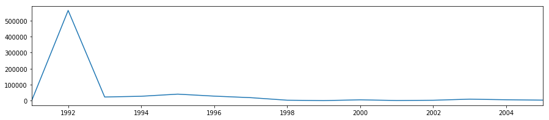

```python
azdias['EINGEFUEGT_AM'].dt.year.value_counts().sort_index().plot(kind='line',figsize=(15,3));
```

```python
azdias.drop('EINGEFUEGT_AM',axis=1,inplace=True)
```

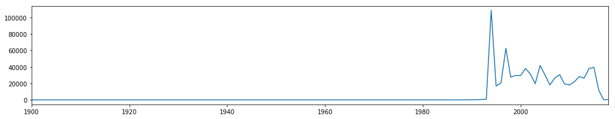

```python
azdias['EINGEZOGENAM_HH_JAHR'].dt.year.value_counts().sort_index().plot(kind='line',figsize=(17,3))
```

```python
azdias.drop('EINGEZOGENAM_HH_JAHR',axis=1,inplace=True)
```

Both datetime feature don't represent anything important, they can be safely dropped

```python
missing_values_table(azdias)
```

```
El dataframe tiene 297 columnas.
De las cuales a 0 le faltan datos.
```

|  | Missing | % of Total Values |
| --- | --- | --- |

```python
azdias=pd.merge(azdias,PRAEGENDE_JUGENDJAHRE[['Value','GENERATION_DECADE', 'Type', 'MOVEMENT']],
        left_on='PRAEGENDE_JUGENDJAHRE', right_on='Value')
```

```python
azdias.drop('PRAEGENDE_JUGENDJAHRE',axis=1,inplace=True)
```

### OHE

```python
columns_OHE=azdias_dtypes[azdias_dtypes.Type=='OHE']['Attribute'].tolist()+['GENERATION_DECADE', 'Type', 'MOVEMENT']
```

```python
for col in columns_OHE:
    if col in azdias.columns:
        print(col,'-------------',azdias[col].nunique())
        print(azdias[col].value_counts())
        print('-------------')
```

```
ANREDE_KZ ------------- 2
2.0    384280
1.0    353008
Name: ANREDE_KZ, dtype: int64
-------------
CAMEO_DEU_2015 ------------- 44
6B    57346
8A    50776
4C    43988
2D    32906
7A    32630
3C    32565
3D    32176
8B    31262
4A    30254
8C    30147
9D    26746
9B    25888
7B    22921
9C    22919
9A    20057
2C    17742
8D    16675
6E    15598
5D    14071
2B    14042
6C    13868
2A    11921
1D    11457
1A    10167
5A     9721
5B     9691
5C     9050
4B     8284
7C     8127
4D     8051
6A     6416
3A     5871
6D     5756
3B     5709
```

[output cut: 329 more lines]

```
 peace movement                                32180
 generation 68 / student protestors            25168
 FDJ / communist party youth organisation      22471
 milk bar / Individualisation                  20103
 war years                                     18635
 reconstruction years                           7376
 Swords into ploughshares                       5063
 opponents to the building of the Wall          3845
Name: Type, dtype: int64
-------------
MOVEMENT ------------- 2
Mainstream    572437
Avantgarde    164851
Name: MOVEMENT, dtype: int64
-------------
```

to avoid the curse of dimensionality I will drop columns with more than 13 categories

```python
columns_to_OHE=[]
columns_too_much=[]
for col in columns_OHE:
    if (col in azdias.columns):
        if (azdias[col].nunique()<=13):
            columns_to_OHE.append(col)
        else:
            columns_too_much.append(col)
```

```python
df_encoded=pd.get_dummies(azdias,columns=columns_to_OHE,drop_first=True)
azdias.drop(columns_to_OHE,axis=1,inplace=True)
azdias = pd.concat([azdias,df_encoded],axis=1)
```

```python
azdias.drop(columns_too_much,axis=1,inplace=True)
```

```python
azdias.columns = [col.split('.')[0] for col in azdias.columns ]
```

```python
azdias.head()
```

|  | AKT_DAT_KL | ALTERSKATEGORIE_FEIN | ANZ_HAUSHALTE_AKTIV | ANZ_HH_TITEL | ANZ_KINDER | ANZ_PERSONEN | ANZ_STATISTISCHE_HAUSHALTE | ANZ_TITEL | ARBEIT | BALLRAUM | ... | Type_ ecological awareness | Type_ economic miracle | Type_ family orientation | Type_ generation 68 / student protestors | Type_ milk bar / Individualisation | Type_ opponents to the building of the Wall | Type_ peace movement | Type_ reconstruction years | Type_ war years | MOVEMENT_Mainstream |
| --- | --- | --- | --- | --- | --- | --- | --- | --- | --- | --- | --- | --- | --- | --- | --- | --- | --- | --- | --- | --- | --- |
| 0 | 9.0 | 21.0 | 11.0 | 0.0 | 0.0 | 2.0 | 12.0 | 0.0 | 3.0 | 6.0 | ... | 0 | 0 | 0 | 0 | 0 | 0 | 0 | 0 | 0 | 1 |
| 1 | 1.0 | 19.0 | 0.0 | 0.0 | 0.0 | 0.0 | 1.0 | 0.0 | 1.0 | 6.0 | ... | 0 | 0 | 0 | 0 | 0 | 0 | 0 | 0 | 0 | 1 |
| 2 | 8.0 | 15.0 | 14.0 | 0.0 | 0.0 | 1.0 | 14.0 | 0.0 | 4.0 | 3.0 | ... | 0 | 0 | 0 | 0 | 0 | 0 | 0 | 0 | 0 | 1 |
| 3 | 1.0 | 20.0 | 1.0 | 0.0 | 0.0 | 0.0 | 1.0 | 0.0 | 3.0 | 7.0 | ... | 0 | 0 | 0 | 0 | 0 | 0 | 0 | 0 | 0 | 1 |
| 4 | 9.0 | 15.0 | 3.0 | 0.0 | 0.0 | 1.0 | 2.0 | 0.0 | 3.0 | 6.0 | ... | 0 | 0 | 0 | 0 | 0 | 0 | 0 | 0 | 0 | 1 |

5 rows × 673 columns

### save structure

```python
azdias=azdias.loc[:,~azdias.columns.duplicated()]
```

```python
azdias.to_csv('data/azdias_structure.csv',index=False)
```

```python
azdias = pd.read_csv('data/azdias_structure.csv')
```

### CLEAN Function

Okay it is clean, but It will be easir to build a function with all the steps to keep consistency and avoid data leakage.

```python
def clean_data(dataframe):

    for col in columns_numeric:
        if col in dataframe.columns:
            dataframe[col]=dataframe[col].astype('float')

    dataframe.fillna(value=values_numeric,inplace=True)
    dataframe.fillna(value=values_mode,inplace=True)

    dataframe['CAMEO_INTL_2015']=dataframe['CAMEO_INTL_2015'].replace('XX',np.nan)
    dataframe['CAMEO_INTL_2015']=dataframe['CAMEO_INTL_2015'].astype('float')

    dataframe['CAMEO_DEUG_2015']=dataframe['CAMEO_DEUG_2015'].replace('X',np.nan)
    dataframe['CAMEO_DEUG_2015']=dataframe['CAMEO_DEUG_2015'].astype('float')

    dataframe['CAMEO_DEU_2015']=dataframe['CAMEO_DEU_2015'].replace('X',np.nan)
    dataframe['CAMEO_DEU_2015']=dataframe['CAMEO_DEU_2015'].replace('XX',np.nan)

    dataframe.replace({'LP_FAMILIE_GROB' : { 4 : 3,
                                      5 : 3,
                                      7 : 6,
                                      8 : 6,
                                      10: 9,
                                      11: 9}}, inplace =True)

    dataframe.replace({'LP_STATUS_GROB' :  { 2 : 1,4 : 3,5 : 3,
                                             7 : 6, 9 : 8,}}, inplace =True)

    clean_df=pd.merge(dataframe,PRAEGENDE_JUGENDJAHRE[['Value','GENERATION_DECADE', 'Type', 'MOVEMENT']],
        left_on='PRAEGENDE_JUGENDJAHRE', right_on='Value',how='left')

    df_encoded=pd.get_dummies(clean_df,columns=columns_to_OHE,drop_first=True)
    clean_df = pd.concat([clean_df,df_encoded],axis=1)

    #clean_df.set_index('LNR',inplace=True)

    return clean_df.loc[:,~clean_df.columns.duplicated()]
```

## Standardization

Then standardization procedure was used to scale features. The advantage of standardization procedure that it does not bound values to a specific range and it is much less affected by outliers.

```python
from sklearn.preprocessing import StandardScaler
Standard_scaler = StandardScaler()
```

```python
standard_scaled_features_df = Standard_scaler.fit_transform(azdias.copy())

azdias_standard_scaler = pd.DataFrame(standard_scaled_features_df, index=azdias.index, columns=azdias.columns)
```

# Part 1: Customer Segmentation Report

The main bulk of your analysis will come in this part of the project. Here, you should use unsupervised learning techniques to describe the relationship between the demographics of the company's existing customers and the general population of Germany. By the end of this part, you should be able to describe parts of the general population that are more likely to be part of the mail-order company's main customer base, and which parts of the general population are less so.

## PCA

Each data point has 412 features, which means the data is 412-dimensional. Clustering algorithms rely on finding clusters in n-dimensional feature space. For higher dimensions, an algorithm like k-means has a difficult time figuring out which features are most important, and the result is, often, noisier clusters.

Some dimensions are not as important as others, wee need values that *vary* between clients.

> We want to find the features that help to separate and group data. We want to find features that cause the **most variance** in the dataset!

The technique I’ll use is called PCA or **principal component analysis**

### Dimensionality Reduction

PCA attempts to reduce the number of features within a dataset while retaining the “principal components”, which are defined as *weighted*, linear combinations of existing features that are designed to be linearly independent and account for the largest possible variability in the data! You can think of this method as taking many features and combining similar or redundant features together to form a new, smaller feature set.

```python
from sklearn.decomposition import PCA
from utils import plt_pca
```

```
90 % variance explained with : 175 components
```

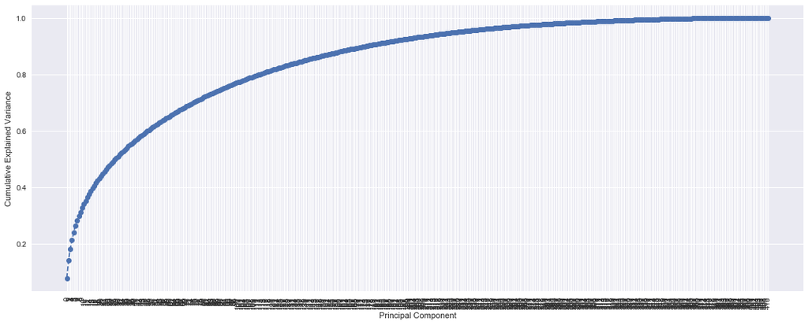

```python
v=plt_pca(azdias_standard_scaler)
```

With 175 components it can be explained 90 % of the variance. Thats a lot of feature less

```python
from utils import display_component
```

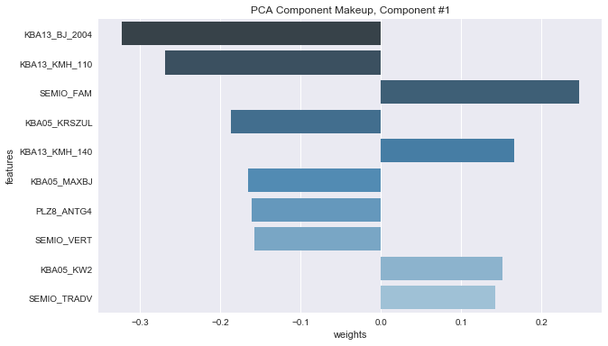

```python
# display makeup of first component
num=1
display_component(v, azdias.columns.values, N_COMPONENTS=175,component_num=num, n_weights=10)
```

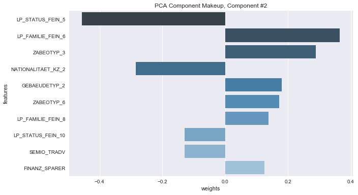

```python
# display makeup of first component
num=2
display_component(v, azdias.columns.values, N_COMPONENTS=175,component_num=num, n_weights=10)
```

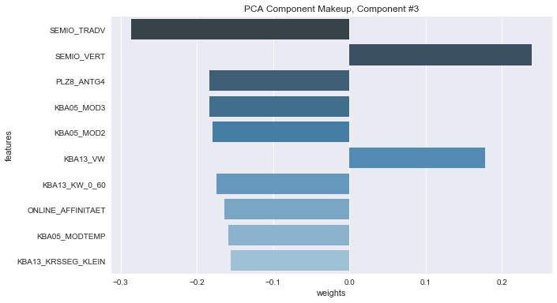

```python
num=3
display_component(v, azdias.columns.values, N_COMPONENTS=175,component_num=num, n_weights=10)
```

```python
# specify top n
top_n = 175
pca = PCA(n_components=top_n)
azdias_PCA=pca.fit_transform(azdias_standard_scaler.copy())
azdias_PCA=pd.DataFrame(azdias_PCA, index=azdias_standard_scaler.index)
azdias_PCA.columns = ['P_'+str(i) for i in range(1,top_n+1)]
azdias_PCA.head()
```

[output not shown]

## Clustering

Elbow method was used to identify an ideal number of clusters for k-means clustering on the PCA-transformed data. Average of sum of squared errors (SSE) within-cluster distances was plotted against number of clusters from 3 to 20.

```python
import datetime
import time
```

```python
from sklearn.cluster import KMeans
from sklearn.metrics import silhouette_score
from utils import elbow_method_computing
```

```python
def silhouette_kmeans(df,clusters,step):
    for K in range(2,clusters,step):
        cluster_kmeans = KMeans(n_clusters=K, random_state=np.random.randint(42), n_jobs=-1)
        cluster_kmeans.fit(df)
        y_kmeans = cluster_kmeans.predict(df)
        centers_=cluster_kmeans.cluster_centers_
        silhouette_avg = silhouette_score(df, y_kmeans,sample_size=int(df.shape[0]/20))
        print('Number of K = {}, The average silhouette_score is :{}'.format(K,silhouette_avg))
```

```python
res_clusters=elbow_method_computing(azdias_PCA,3,20, 2)
```

```
3 Time Training :0.83 minutes
5 Time Training :1.01 minutes
7 Time Training :1.68 minutes
9 Time Training :2.67 minutes
11 Time Training :2.87 minutes
13 Time Training :2.52 minutes
15 Time Training :2.83 minutes
17 Time Training :3.71 minutes
19 Time Training :3.28 minutes
```

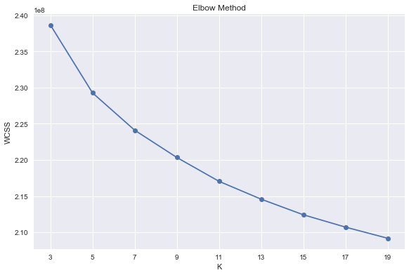

```python
plt.plot(res_clusters['k'],res_clusters['wcss'],marker='o');
plt.xticks(res_clusters['k']);
plt.xlabel('K');
plt.tight_layout()
plt.ylabel('WCSS');
plt.title('Elbow Method');
```

```python
silhouette_kmeans(azdias_PCA,20,4)
```

```
Number of K = 2, The average silhouette_score is :0.057703679896043664
Number of K = 6, The average silhouette_score is :0.03654305940152835
Number of K = 10, The average silhouette_score is :0.029680737903427474
Number of K = 14, The average silhouette_score is :0.026106969773206264
Number of K = 18, The average silhouette_score is :0.024958757674444193
```

The silhouette_score is not the best, ideally a good score is above 0.5, but we are using a sample since this process takes a lot of time, so don't panic yet, maybe something to check later with more time.

```python
#k-means model with n_clusters =  7
kmeans = KMeans(n_clusters=7, random_state=42, n_jobs=-1)
labels_azdias = kmeans.fit_predict(azdias_PCA)
```

```python
import matplotlib.cm as cm
```

```python
def plot_clusters(df,n_clusters,centroids,labels):
    #import matplotlib.pyplot as plt
    plt.figure(figsize=[16,5])
    #Plot showing the actual clusters formed
    colors = cm.nipy_spectral(labels.astype(float) / n_clusters)
    plt.scatter(df.iloc[:, 0], df.iloc[:, 1], marker='.', s=30, lw=0, alpha=0.7,c=colors, edgecolor='k')
    # Labeling the clusters
    centers = centroids
    # Draw white circles at cluster centers
    plt.scatter(centers[:, 0], centers[:, 1], marker='o',c="white", alpha=1, s=200, edgecolor='k')
    for i, c in enumerate(centers):
        plt.scatter(c[0], c[1], marker='$%d$' % i, alpha=1,s=50, edgecolor='k')

    plt.title("The visualization of the clustered data.")
    plt.xlabel("Feature space for the 1st feature")
    plt.ylabel("Feature space for the 2nd feature")

    plt.suptitle(("Analysis for KMeans clustering "
                  "with n_clusters = %d" % n_clusters),
                 fontsize=14, fontweight='bold')
```

it look kind of nice, but still we can see that some cluster might be overlaping, so this project still needs time, maybe with some more data preprations.

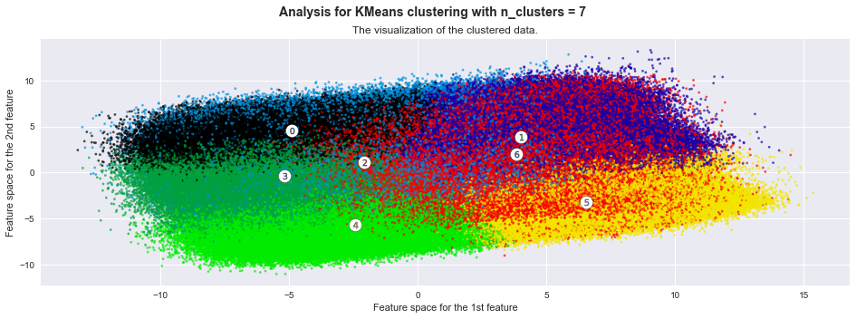

```python
y_assigment=plot_clusters(azdias_PCA,7,kmeans.cluster_centers_,labels_azdias)
```

```python
print(pd.Series(labels_azdias).value_counts())
```

```
4    129663
1    125501
5    124102
3    115303
0    101609
2     74431
6     66679
dtype: int64
```

```python
pd.Series(labels_azdias).value_counts(normalize=True)
```

```
4    0.175865
1    0.170220
5    0.168322
3    0.156388
0    0.137815
2    0.100952
6    0.090438
dtype: float64
```

### PIPELINE

```python
from sklearn.pipeline import Pipeline
```

```python
cluster_pipeline=Pipeline([('StandardScaler', StandardScaler()),
                           ('PCA', PCA(n_components=top_n)),
                           ('KMeans', KMeans(n_clusters=7, random_state=42, n_jobs=-1))])
```

```python
#TO DO !
#cluster_pipeline.fit(azdias)
```

## Load Customer Data

```python
customers = pd.read_csv('data/Udacity_CUSTOMERS_052018.csv',sep=';')
```

## Clean Customers

```python
clean_customers = clean_data(customers)

# FOR SOME REASONS I GOT A MULTIINDEX : THIS SOLVES THE PROBLEM
clean_customers=clean_df.loc[:,~clean_df.columns.duplicated()]
```

```python
# Correct de columns names
clean_customers.columns = [col.split('.')[0] for col in clean_customers.columns ]
```

```python
#  Check for missing column in `clean_customers`
miss_attribute = list(azdias.columns[~azdias.columns.isin(clean_customers.columns)])
miss_attribute
```

```
['GEBAEUDETYP_5']
```

```python
#Default value  is  0
clean_customers['GEBAEUDETYP_5'] = 0
clean_customers['GEBAEUDETYP_5'] = clean_customers['GEBAEUDETYP_5'].astype('uint8')
```

```python
clean_customers=clean_customers[azdias.columns]
```

```python
# FOR SOME REASONS I GOT A MULTIINDEX : THIS SOLVES THE PROBLEM
clean_customers=clean_customers.loc[:,~clean_customers.columns.duplicated()]
```

```python
#Default value  is  0
clean_customers['CAMEO_DEUG_2015']=clean_customers['CAMEO_DEUG_2015'].fillna(0)
clean_customers['CAMEO_INTL_2015']=clean_customers['CAMEO_INTL_2015'].fillna(0)
```

```python
clean_customers.shape
```

```
(143165, 412)
```

## Predict

```python
#cluster_pipeline.predict(clean_customers)

new_income_customers_scaler = Standard_scaler.transform(clean_customers)
new_income_customers_PCA    = pca.transform(new_income_customers_scaler)
labels_predict              = kmeans.predict(new_income_customers_PCA)
```

```python
clean_customers['cluster'] = labels_predict


clean_customers['cluster'].value_counts()
```

```
0    63341
3    27544
2    24737
1    16287
4     5690
6     3718
5     1848
Name: cluster, dtype: int64
```

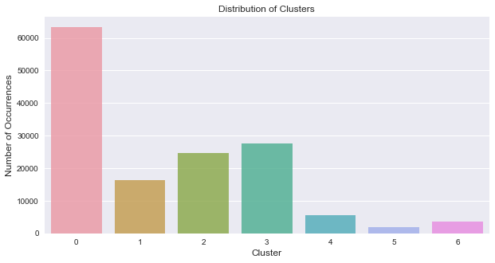

```python
count  = clean_customers['cluster'].value_counts()
count  = count[:10,]
plt.figure(figsize=(10,5))
sns.barplot(count.index, count.values, alpha=0.8)
plt.title('Distribution of Clusters')
plt.ylabel('Number of Occurrences', fontsize=12)
plt.xlabel('Cluster', fontsize=12)
plt.show()
```

**Discussion**

44 % percent of the customers' data fit in the cluster with label 0.

The company can take this population as future customers in Germany, since they share similarities.

With the azdias file we can see that 14 % of the clients are located in that cluster. Those 101609 are the targeted clusters.

```python
azdias_PCA['Cluster'] =labels_azdias
```

# Part 2: Supervised Learning Model

We have found which parts of the population are more likely to be customers of the mail-order company, it's time to build a prediction model.

Each of the rows in the "MAILOUT" data files represents an individual that was targeted for a mailout campaign. Ideally, we should be able to use the demographic information from each individual to decide whether or not it will be worth it to include that person in the campaign.

The "MAILOUT" data has been split into two approximately equal parts, each with almost 43 000 data rows. In this part, you can verify your model with the "TRAIN" partition, which includes a column, "RESPONSE", that states whether or not a person became a customer of the company following the campaign. In the next part, you'll need to create predictions on the "TEST" partition, where the "RESPONSE" column has been withheld.

```python
mailout_train = pd.read_csv('data/Udacity_MAILOUT_052018_TRAIN.csv', sep=';')
```

```python
mailout_train['RESPONSE'].value_counts()
```

```
0    42430
1      532
Name: RESPONSE, dtype: int64
```

```python
mailout_train['RESPONSE'].value_counts(normalize=True)
```

```
0    0.987617
1    0.012383
Name: RESPONSE, dtype: float64
```

Yep... It is a umbalanced problem !

## Clean Data

```python
clean_mailout_train = clean_data(mailout_train)

# Correct Unknown MultiIndex
clean_mailout_train=clean_mailout_train.loc[:,~clean_mailout_train.columns.duplicated()]
```

```python
clean_mailout_train.set_index('LNR',inplace=True)
```

```python
clean_mailout_train.columns = [col.split('.')[0] for col in clean_mailout_train.columns ]
```

```python
#Default value  is  0
clean_mailout_train['GEBAEUDETYP_5'] = 0
clean_mailout_train['GEBAEUDETYP_5'] = clean_mailout_train['GEBAEUDETYP_5'].astype('uint8')
```

```python
from sklearn.model_selection import train_test_split,GridSearchCV,RandomizedSearchCV
from sklearn.metrics import roc_auc_score,recall_score,precision_score,f1_score,confusion_matrix,accuracy_score
from sklearn.ensemble import RandomForestClassifier
from sklearn.linear_model import LogisticRegression
from xgboost import XGBClassifier
from imblearn.pipeline import Pipeline as make_pipeline_imb
from imblearn.over_sampling import SMOTE
from sklearn.preprocessing import MinMaxScaler
```

## DataSet - Split

```python
clean_mailout_train.head()
```

| LNR | AGER_TYP | AKT_DAT_KL | ALTER_HH | ALTER_KIND1 | ALTER_KIND2 | ALTER_KIND3 | ALTER_KIND4 | ALTERSKATEGORIE_FEIN | ANZ_HAUSHALTE_AKTIV | ANZ_HH_TITEL | ... | Type_ ecological awareness | Type_ economic miracle | Type_ family orientation | Type_ generation 68 / student protestors | Type_ milk bar / Individualisation | Type_ opponents to the building of the Wall | Type_ peace movement | Type_ reconstruction years | Type_ war years | MOVEMENT_Mainstream |
| --- | --- | --- | --- | --- | --- | --- | --- | --- | --- | --- | --- | --- | --- | --- | --- | --- | --- | --- | --- | --- | --- |
| 1763 | 2 | 1.0 | 8.0 | NaN | NaN | NaN | NaN | 8.0 | 15.0 | 0.0 | ... | 0 | 0 | 0 | 0 | 0 | 0 | 0 | 0 | 1 | 1 |
| 1771 | 1 | 4.0 | 13.0 | NaN | NaN | NaN | NaN | 13.0 | 1.0 | 0.0 | ... | 0 | 0 | 1 | 0 | 0 | 0 | 0 | 0 | 0 | 1 |
| 1776 | 1 | 1.0 | 9.0 | NaN | NaN | NaN | NaN | 7.0 | 0.0 | 0.0 | ... | 0 | 0 | 0 | 0 | 0 | 0 | 0 | 1 | 0 | 0 |
| 1460 | 2 | 1.0 | 6.0 | NaN | NaN | NaN | NaN | 6.0 | 4.0 | 0.0 | ... | 0 | 0 | 0 | 0 | 0 | 0 | 0 | 1 | 0 | 0 |
| 1783 | 2 | 1.0 | 9.0 | NaN | NaN | NaN | NaN | 9.0 | 53.0 | 0.0 | ... | 0 | 1 | 0 | 0 | 0 | 0 | 0 | 0 | 0 | 1 |

5 rows × 526 columns

```python
X = clean_mailout_train[azdias.columns].drop('Value',axis=1)
y = clean_mailout_train['RESPONSE']
```

```python
X_train, X_test, y_train, y_test = train_test_split(X, y, test_size=0.3, random_state=42)
```

## Modeling

```python
import datetime
import time
```

```python
LR_param = {'model__penalty': ['l2'],
            'model__C': [0.001,0.1,1,10]}

XGBoost_param = {'model__n_estimators': [50,100,150],
                 'model__max_depth':range(5,10,1),}

RFC_param = {'model__n_estimators': [50,100,150]}
```

```python
models_param = [LR_param,
                RFC_param,
                XGBoost_param]


classifiers=['Logistic Regression',
             'RandomForestClassifier',
             'XGBoost']

models=[LogisticRegression(),
        RandomForestClassifier(),
        XGBClassifier()]
```

```python
# Ciclo iterativo para probar varios modelos
Data_results=pd.DataFrame()
scores = {}

for Name,model,params in zip(classifiers,models,models_param):
    clf_pipe =  make_pipeline_imb([('MinMaxScaler', MinMaxScaler()),
                                   #('PCA'  ,PCA(n_components=top_n)),
                                   #('SMOTE', SMOTE(random_state=42)),
                                   ('model', model)])

    print(f'{Name} Start Training at :{datetime.datetime.now()} ')
    clf = RandomizedSearchCV(clf_pipe,param_distributions=params,scoring = 'roc_auc',cv=3,verbose=0,n_jobs=4)
    tic = time.time()
    clf.fit(X_train,y_train)
    toc = time.time()
    print('Time Training :{:.2f} minutes '.format((toc-tic)/60))
    print(f'Best Params   :{clf.best_params_}')
    y_pred=clf.predict(X_test)
    scores['Model Name'] = Name
    scores['ROC AUC']=roc_auc_score(y_test,clf.predict_proba(X_test)[:,1])
    scores['Precision']=precision_score(y_test, y_pred)
    scores['Recall']=recall_score(y_test, y_pred)
    scores['F1']=f1_score(y_test, y_pred)
    print(f'ROC AUC       :{scores["ROC AUC"]}')
    print(f'Precision     :{scores["Precision"]}')
    print(f'Recall        :{scores["Recall"]}')
    print(f'F1            :{scores["F1"]}')
    print('\n')
    D=pd.DataFrame(scores,index=[0])
    Data_results=pd.concat([Data_results, D])
```

```
Logistic Regression Start Training at :2019-12-09 12:26:49.482005
Time Training :0.49 minutes
Best Params   :{'model__penalty': 'l2', 'model__C': 1}
ROC AUC       :0.6369051864287139
Precision     :0.02397901835893593
Recall        :0.37209302325581395
F1            :0.04505455825413586


RandomForestClassifier Start Training at :2019-12-09 12:27:18.894546
Time Training :3.16 minutes
Best Params   :{'model__n_estimators': 150}
ROC AUC       :0.6385796068620835
Precision     :0.018796992481203006
Recall        :0.05813953488372093
F1            :0.02840909090909091


XGBoost Start Training at :2019-12-09 12:30:29.386018
Time Training :15.23 minutes
Best Params   :{'model__n_estimators': 100, 'model__max_depth': 5}
ROC AUC       :0.6854533210443446
Precision     :0.02702702702702703
Recall        :0.046511627906976744
F1            :0.03418803418803419
```

## Feature Importance

```python
features = clf.best_estimator_.named_steps["model"].feature_importances_
```

```python
nombres=X_train.columns
```

```python
df_importance = pd.DataFrame({'nombres':nombres,'features':features})
#df_importance.set_index('nombres', inplace=True)
df_importance.sort_values(['features'],ascending=False).head(25)
```

|  | nombres | features |
| --- | --- | --- |
| 215 | KOMBIALTER | 0.041587 |
| 274 | FINANZTYP_4 | 0.035775 |
| 17 | D19_SOZIALES | 0.033203 |
| 105 | KBA13_ANTG4 | 0.030385 |
| 267 | D19_KONSUMTYP_3 | 0.027271 |
| 57 | KBA05_HERSTTEMP | 0.023180 |
| 65 | KBA05_KRSZUL | 0.019810 |
| 352 | ZABEOTYP_3 | 0.018759 |
| 163 | KBA13_KRSHERST_AUDI_VW | 0.017805 |
| 62 | KBA05_KRSKLEIN | 0.016658 |
| 276 | FINANZTYP_6 | 0.015695 |
| 165 | KBA13_KRSHERST_FORD_OPEL | 0.015468 |
| 124 | KBA13_CCM_1800 | 0.015220 |
| 69 | KBA05_MAXAH | 0.014335 |
| 212 | KBA13_VORB_3 | 0.014269 |
| 70 | KBA05_MAXBJ | 0.013838 |
| 80 | KBA05_MOTRAD | 0.012491 |
| 26 | FINANZ_HAUSBAUER | 0.012020 |
| 35 | KBA05_ALTER1 | 0.011296 |
| 346 | RETOURTYP_BK_S_5 | 0.011062 |
| 199 | KBA13_SEG_SONSTIGE | 0.011013 |
| 14 | D19_BUCH_CD | 0.010957 |
| 249 | UMFELD_JUNG | 0.010943 |
| 186 | KBA13_OPEL | 0.010658 |
| 107 | KBA13_AUDI | 0.010232 |

## Save Model

```python
# save the model to disk
import pickle
```

```python
filename = 'best_classifier.sav'
pickle.dump(clf, open(filename, 'wb'))
```

```python
filename = 'best_classifier.sav'
pickle.dump(clf, open(filename, 'wb'))
```

# Part 3: Kaggle Competition

Now that you've created a model to predict which individuals are most likely to respond to a mailout campaign, it's time to test that model in competition through Kaggle. If you click on the link [here](http://www.kaggle.com/t/21e6d45d4c574c7fa2d868f0e8c83140), you'll be taken to the competition page where, if you have a Kaggle account, you can enter. If you're one of the top performers, you may have the chance to be contacted by a hiring manager from Arvato or Bertelsmann for an interview!

Your entry to the competition should be a CSV file with two columns. The first column should be a copy of "LNR", which acts as an ID number for each individual in the "TEST" partition. The second column, "RESPONSE", should be some measure of how likely each individual became a customer – this might not be a straightforward probability. As you should have found in Part 2, there is a large output class imbalance, where most individuals did not respond to the mailout. Thus, predicting individual classes and using accuracy does not seem to be an appropriate performance evaluation method. Instead, the competition will be using AUC to evaluate performance. The exact values of the "RESPONSE" column do not matter as much: only that the higher values try to capture as many of the actual customers as possible, early in the ROC curve sweep.

```python
mailout_test = pd.read_csv('data/Udacity_MAILOUT_052018_TEST.csv', sep=';')
```

```python
for col in columns_numeric:
        if col in mailout_test.columns:
            mailout_test[col]=mailout_test[col].astype('float')

mailout_test['CAMEO_INTL_2015']=mailout_test['CAMEO_INTL_2015'].replace('XX',np.nan)
mailout_test['CAMEO_INTL_2015']=mailout_test['CAMEO_INTL_2015'].astype('float')

mailout_test['CAMEO_DEUG_2015']=mailout_test['CAMEO_DEUG_2015'].replace('X',np.nan)
mailout_test['CAMEO_DEUG_2015']=mailout_test['CAMEO_DEUG_2015'].astype('float')

mailout_test['CAMEO_DEU_2015']=mailout_test['CAMEO_DEU_2015'].replace('X',np.nan)
mailout_test['CAMEO_DEU_2015']=mailout_test['CAMEO_DEU_2015'].replace('XX',np.nan)

mailout_test.fillna(value=values_numeric,inplace=True)
mailout_test.fillna(value=values_mode,inplace=True)

mailout_test.replace({'LP_FAMILIE_GROB' : { 4 : 3,
                                      5 : 3,
                                      7 : 6,
                                      8 : 6,
                                      10: 9,
                                      11: 9}}, inplace =True)

mailout_test.replace({'LP_STATUS_GROB' :  { 2 : 1,4 : 3,5 : 3,
                                             7 : 6, 9 : 8,}}, inplace =True)

clean_df_mailout_test=pd.merge(mailout_test,PRAEGENDE_JUGENDJAHRE[['Value','GENERATION_DECADE', 'Type', 'MOVEMENT']],
left_on='PRAEGENDE_JUGENDJAHRE', right_on='Value',how='left')

df_encoded=pd.get_dummies(clean_df_mailout_test,columns=columns_to_OHE,drop_first=True)
clean_df_mailout_test = pd.concat([clean_df_mailout_test,df_encoded],axis=1)

clean_df_mailout_test=clean_df_mailout_test.loc[:,~clean_df_mailout_test.columns.duplicated()]
```

```python
clean_df_mailout_test.set_index('LNR',inplace=True)
```

```python
clean_df_mailout_test.columns = [col.split('.')[0] for col in clean_df_mailout_test.columns ]
```

```python
clean_df_mailout_test=clean_df_mailout_test.loc[:,~clean_df_mailout_test.columns.duplicated()]
```

```python
#Default value  is  0
clean_df_mailout_test['GEBAEUDETYP_5'] = 0
clean_df_mailout_test['GEBAEUDETYP_5'] = clean_df_mailout_test['GEBAEUDETYP_5'].astype('uint8')
```

```python
clean_df_mailout_test.shape
```

```
(42833, 526)
```

```python
y_prob=clf.predict_proba(clean_df_mailout_test[azdias.columns].drop('Value',axis=1))[:,1]
```

```python
clean_df_mailout_test['RESPONSE'] = y_prob
```

```python
clean_df_mailout_test.reset_index()[['LNR','RESPONSE']].to_csv('data/submission.csv',index=False)
```

[figure not shown]

not so good... still a lot to look for , but I am in rush !

# References

1. [Average Advertisin Costs](https://www.lyfemarketing.com/blog/average-advertising-costs/)
2. [Silhoutte Score](https://scikit-learn.org/stable/modules/generated/sklearn.metrics.silhouette_score.html)
3. [Elbow Method Heuristic](https://www.oreilly.com/library/view/statistics-for-machine/9781788295758/c71ea970-0f3c-4973-8d3a-b09a7a6553c1.xhtml)
4. [ROC Curve AUC](https://scikit-learn.org/stable/modules/generated/sklearn.metrics.roc_auc_score.html)
5. [K-MEANS](https://scikit-learn.org/stable/modules/generated/sklearn.cluster.KMeans.html)